# Exp6 Analysis

## Exploratory Analysis

This exploratory analyusis involves the factors of contingency awareness from the guessing trials and the awareness questionnaire responses

#### Contingency Awareness guessing trials

These plots show the overall accuracy of the participants in the guessing trials that were spread across the experiment.

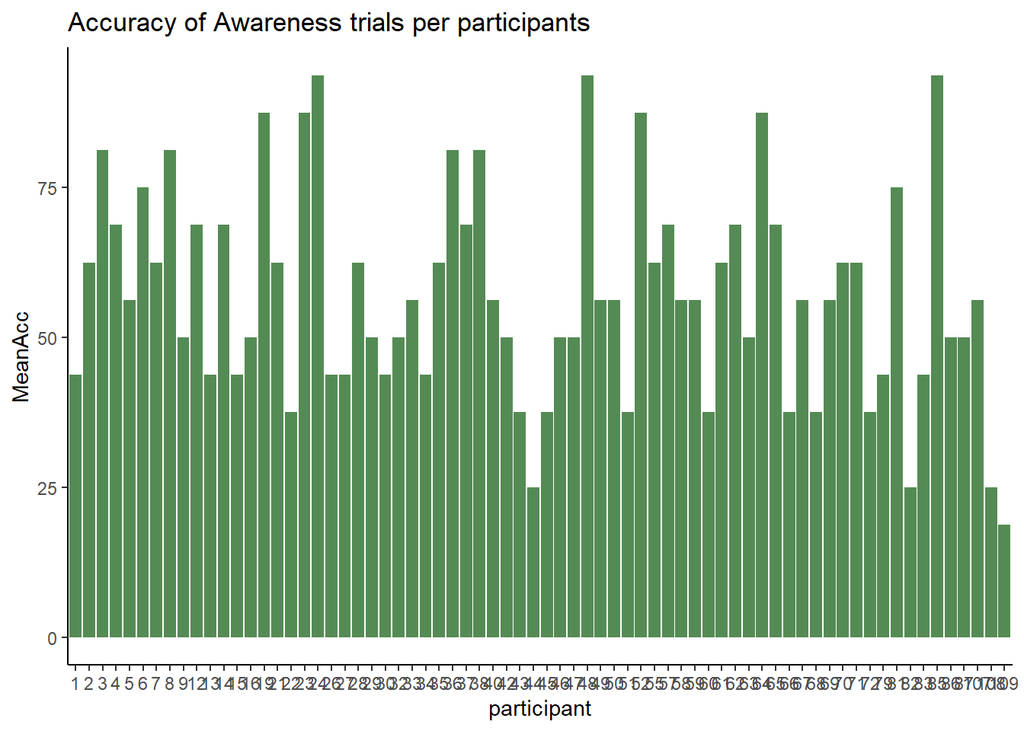

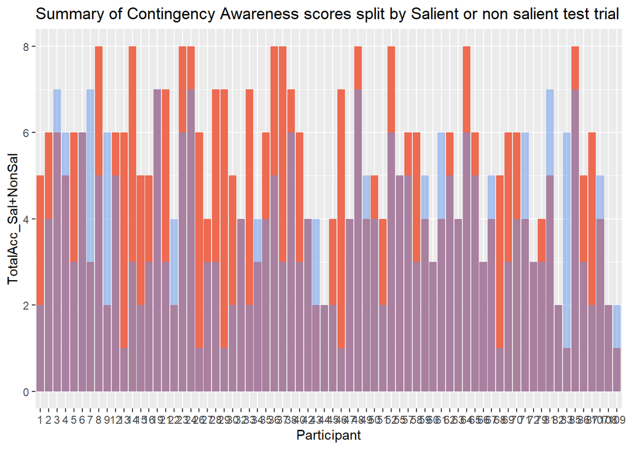

### Awareness Questionnaire

The accuracy for the questions related to the salient letter are aggregated and given an overall score of 1 if they answered both the questions right and 0 if one or both are wrong.

This variable (allSalAware) is then included as a factor in the main aggregate df containing the validity and saliency effect for test trials

It does not show any significant effect. The graph however looks like as if those who do not have awareness show a larger validity effect for salient trials compared to those who do not. This is shown in the table below

- **ANOVA**:

  |  | Effect | DFn | DFd | SSn | SSd | F | p | p<.05 | ges |
  | --- | --- | --- | --- | --- | --- | --- | --- | --- | --- |
  | **1** | (Intercept) | 1 | 68 | 93504677 | 997378 | 6375 | 6.061e-69 | * | 0.9868 |
  | **2** | allSalAware | 1 | 68 | 30259 | 997378 | 2.063 | 0.1555 |  | 0.02363 |
  | **3** | Saliency | 1 | 68 | 639.2 | 66255 | 0.6561 | 0.4208 |  | 0.000511 |
  | **5** | Validity | 1 | 68 | 5165 | 105140 | 3.341 | 0.07197 |  | 0.004114 |
  | **4** | allSalAware:Saliency | 1 | 68 | 120.7 | 66255 | 0.1238 | 0.726 |  | 9.65e-05 |
  | **6** | allSalAware:Validity | 1 | 68 | 169.3 | 105140 | 0.1095 | 0.7418 |  | 0.0001354 |
  | **7** | Saliency:Validity | 1 | 68 | 630.7 | 81514 | 0.5261 | 0.4707 |  | 0.0005042 |
  | **8** | allSalAware:Saliency:Validity | 1 | 68 | 61.95 | 81514 | 0.05168 | 0.8209 |  | 4.954e-05 |

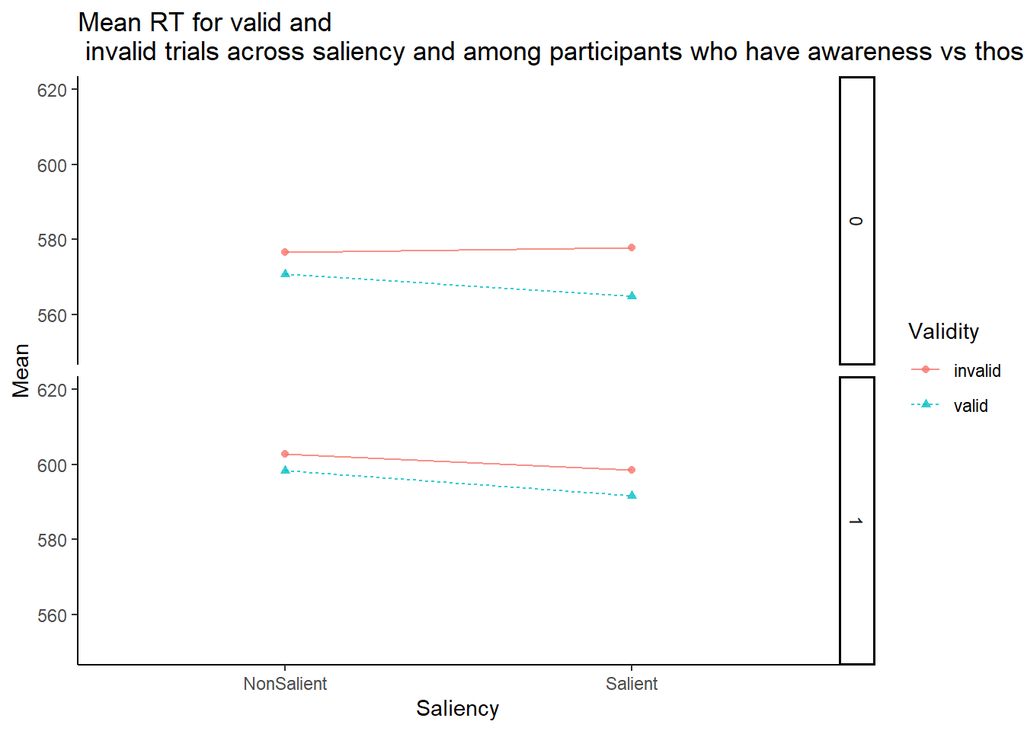

| allSalAware | Saliency | N | Mean | SD | FLSD |
| --- | --- | --- | --- | --- | --- |
| 0 | NonSalient | 55 | 5.909 | 49.69 | 23.36 |
| 0 | Salient | 55 | 12.9 | 57.76 | 23.36 |
| 1 | NonSalient | 15 | 4.412 | 46.26 | 23.36 |
| 1 | Salient | 15 | 6.813 | 46.15 | 23.36 |

- **ANOVA**:

  |  | Effect | DFn | DFd | SSn | SSd | F | p | p<.05 | ges |
  | --- | --- | --- | --- | --- | --- | --- | --- | --- | --- |
  | **1** | (Intercept) | 1 | 68 | 88908178 | 750110 | 8060 | 2.249e-72 | * | 0.9899 |
  | **2** | allSalAware | 1 | 68 | 21275 | 750110 | 1.929 | 0.1694 |  | 0.02295 |
  | **3** | Saliency | 1 | 68 | 53.04 | 41134 | 0.08768 | 0.7681 |  | 5.855e-05 |
  | **5** | Validity | 1 | 68 | 9207 | 52630 | 11.9 | 0.0009704 | * | 0.01006 |
  | **4** | allSalAware:Saliency | 1 | 68 | 108.1 | 41134 | 0.1788 | 0.6738 |  | 0.0001194 |
  | **6** | allSalAware:Validity | 1 | 68 | 366.6 | 52630 | 0.4737 | 0.4936 |  | 0.0004046 |
  | **7** | Saliency:Validity | 1 | 68 | 328.4 | 61933 | 0.3606 | 0.5502 |  | 0.0003624 |
  | **8** | allSalAware:Saliency:Validity | 1 | 68 | 268.8 | 61933 | 0.2951 | 0.5887 |  | 0.0002966 |

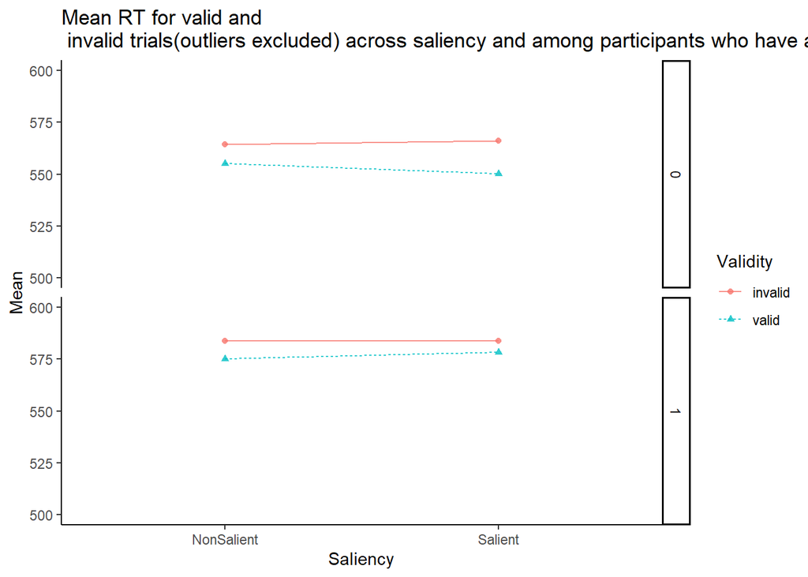

| allSalAware | Saliency | N | Mean | SD | FLSD |
| --- | --- | --- | --- | --- | --- |
| 0 | NonSalient | 55 | 9.474 | 36.69 | 20.36 |
| 0 | Salient | 55 | 15.85 | 46.88 | 20.36 |
| 1 | NonSalient | 15 | 8.672 | 35.58 | 20.36 |
| 1 | Salient | 15 | 5.5 | 37.83 | 20.36 |

Now we split the data and only analyze participants with awareness.

Here we see that none of the effects are significant anymore (which was also visually evident from the graph)

- **ANOVA**:

  | Effect | DFn | DFd | SSn | SSd | F | p | p<.05 | ges |
  | --- | --- | --- | --- | --- | --- | --- | --- | --- |
  | (Intercept) | 1 | 14 | 21440873 | 231368 | 1297 | 3.326e-15 | * | 0.9875 |
  | Saliency | 1 | 14 | 459.7 | 10715 | 0.6006 | 0.4512 |  | 0.001687 |
  | Validity | 1 | 14 | 472.5 | 18275 | 0.362 | 0.557 |  | 0.001734 |
  | Saliency:Validity | 1 | 14 | 21.61 | 11611 | 0.02605 | 0.8741 |  | 7.944e-05 |

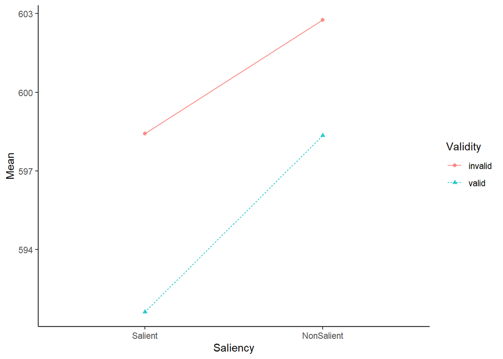

| Saliency | N | Mean | SD | FLSD |
| --- | --- | --- | --- | --- |
| NonSalient | 15 | 4.412 | 46.26 | 31.9 |
| Salient | 15 | 6.813 | 46.15 | 31.9 |

But now since the graph for participants with no awareness seemed like to have a larger effect, I further analyzed data of only those without awareness This also did not show a significant interaction

- **ANOVA**:

  | Effect | DFn | DFd | SSn | SSd | F | p | p<.05 | ges |
  | --- | --- | --- | --- | --- | --- | --- | --- | --- |
  | (Intercept) | 1 | 54 | 72094062 | 766010 | 5082 | 4.198e-55 | * | 0.9866 |
  | Saliency | 1 | 54 | 300.2 | 55540 | 0.2919 | 0.5912 |  | 0.0003068 |
  | Validity | 1 | 54 | 4862 | 86865 | 3.023 | 0.08781 |  | 0.004945 |
  | Saliency:Validity | 1 | 54 | 671 | 69902 | 0.5184 | 0.4747 |  | 0.0006854 |

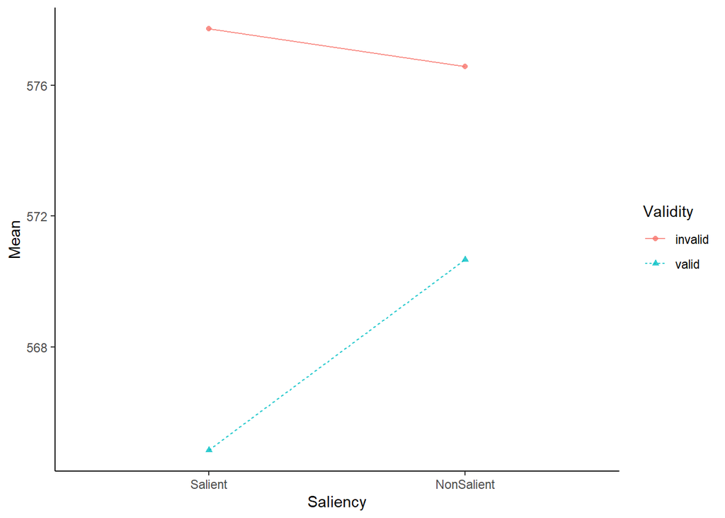

| Saliency | N | Mean | SD | FLSD |
| --- | --- | --- | --- | --- |
| NonSalient | 55 | 5.909 | 49.69 | 19.45 |
| Salient | 55 | 12.9 | 57.76 | 19.45 |